# Information Theory: Lab 4: Conditional entropy of natural languages

## 1. Description of the task

All tasks realized during classes are .pdf files formatted similarly as this document. The tasks will be of different kinds. Every task will be appropriately marked: • Tasks to be realized during classes are marked with (squre) – you won’t get points for them, but you still need to do them. • Pointed tasks to be realized during classes are marked with ✸ – you need to do them during class and show to your teacher, and in the case you don’t manage to do so (or are absent) they become your homework (*). • Homeworks are marked with* – they also have assigned a number of points, and you need to deliver them to your teacher before a deadline (usually before the next class). • You may use any programming language you like for the programming tasks, but you are limited to only the standard library of that language and libraries widely accepted as standard.

## 2. Objective

During this class we will apply in practice conditional entropy to the analysis of natural languages.

## 3. How do we know that hieroglyphs are a meaningful text?

Finding the Rosetta stone was crucial for deciphering Egyptian hieroglyphs. It was found in 1799 during Napoleon’s expedition to Egypt, and later in 1801 taken by Great Britain as a result of peace negotiations.

The stone tablet contains the same text written in three ways: hieroglyphs, demotic (“everyday-use hieroglyphs”), and Greek. Based on these findings, the bigger part of the hieroglyphic writing system was deciphered by 1822.

Finding similar translations allowed to decipher some other ancient languages. The Mesopotamian language was deciphered in 1857, and the Mayan language in 1952. However, there are still other ancient languages that remain incomprehensible to us.

The main question for those incomprehensible texts is: are those pictograms a system of writing at all? For example, the Indus Valley Civilization, which existed between 3300 and 1300 BC, left behind clay tablets containing several symbols each. Archeologists long disputed, whether it is writing system at all. The conditional entropy analysis gave the positive answer to this question.

## 4. Conditional entropy (recap)

Conditional entropy H(Y |X) measures the amount of uncertainty (entropy) of a random variable Y that remains, if we know the value of a random variable X. We can compute it using the formula:

$$ H(Y|X) =-\sum_{x \in X, y \in Y}p(x,y) · \log p(y|x) $$

where p(x, y) is the joint probability of events x and y, and p(y|x) is the probability of an event y dependent on x. The above formula can be derived from:

$$ H(Y|X) = \sum_{x \in X}p(x) · H(Y|X=x) = \sum_{x \in X}p(x) · [ -\sum_{y \in Y}p(y|x · \log p(y|x))] $$

Conditional entropy is used, for example, in the decision tree learning algorithms to (sort of greedily) select at each step an attribute which will minimize the conditional entropy of a decision attribute. When applying the above definition to the analysis of language, p(x, y) is the joint probability of an n-gram x and a following character/word y against all other possible (n+1)-grams in the corpus, and p(y|x) is the probability of y occurring after x. In the homework, we will consider the conditional entropy of rank n, where n denotes the length of an n-gram x. Conditional entropy H(Y |X) can be also computed as a difference between joint entropy H(Y, X) and (marginal) entropy H(X):

$$ H(Y|X) = H(Y, X) - H(X) = -\sum_{x \in X , y \in Y}p(x, y) · \log p(y,x) + \sum_{x \in X} p(x)·\log p(x)$$

## 5. The language of dolphins and the search for extraterrestrial civilizations

When researching the language of the civilization of ancient Indus, as well as all modern languages, we will notice that conditional entropy of different languages is similar and decreases as the rank becomes bigger. This is true for both the conditional entropy of characters and words. This is an expected result. Imagine that our task is to guess a word selected from a book. Our options are limited and we can only guess randomly, alternatively choose the most frequent word. If instead we were supposed to do the same but given the word that was before, our probability of success would be much higher. The task will be even simpler when we are provided with two previous words. The set of possible words decreases (for example, because of different parts of speech), certain words become much more probable (for example, “wise man” vs “wise politician”), or both of those effects at the same time. Since our uncertainty decreases, we can infer that the entropy also does so. A similar analysis was conducted on the noises generated by different species of animals in order to compare the complexity of their communication. The animals with high intelligence (or rather: the intelligence we as humans would be more apt to call as such), like for example dolphins, have the similar entropy characteristic of their communication system as human languages. This line of research interested the astronomer and astrophysicist Frank Drake. In 1959 he initiated the SETI (Search for Extraterrestrial Intelligence) project, which is continued to this day. The goal of this project is to find extraterrestrial civilizations by capturing and analyzing the radio and light signals coming to us from space. This search is conducted using, among others, the conditional entropy of signals.

## 6. TASK

Detecting if a text was written in a natural language

For this task will be needed text corpuses, which can be downloaded from http://www.cs.put.poznan.pl/ibladek/students/timkod/lab3.zip. Compute the entropies of characters and words, and their conditional entropies of higher ranks (it may be useful to think here about standard entropy as simply a conditional entropy of rank 0) for a sample of English (file norm_wiki_en.txt). (2pt)

```python
def loading_file(file_name):
    with open(file_name) as file:
        text = file.readlines()[0]
    return text.replace('\n', ' ').strip()
```

```python
text = loading_file('samples/norm_wiki_eo.txt')
#print(text[:100])
```

```python
from collections import Counter

def count_ngrams_prob(text, rank):
    n=rank+1
    # Counting n-grams
    n_grams = [text[i:i+n] for i in range(len(text)-n+1)]
    n_grams_counter = Counter(n_grams)
    # Counting probabilities
    n_grams_prob = {}
    for n_gram in n_grams_counter:
        n_grams_prob[n_gram] = n_grams_counter[n_gram] / len(n_grams)
    # sort n_grams_prob by values
    n_grams_prob = dict(sorted(n_grams_prob.items(), key=lambda item: item[1], reverse=True))
    return n_grams_prob

def count_words_prob(text, rank):
    #split text into pair of words
    input_words=text.split()
    group_of_words=[]
    for i in range(len(input_words)-rank):
        group_of_words.append(' '.join(input_words[i:i+rank+1]))
    words_counter = Counter(group_of_words)
    # Counting probabilities
    words_prob = {}
    for word in words_counter:
        words_prob[word] = words_counter[word] / len(group_of_words)
    # sort words_prob by values
    words_prob = dict(sorted(words_prob.items(), key=lambda item: item[1], reverse=True))
    return words_prob
```

```python
#print(list(count_ngrams_prob(text, 2).items())[:10])
#print(list(count_words_prob(text, 2).items())[:10])
```

```python
import math

def entropy(text):
    n_grams_prob = count_ngrams_prob(text, 0)
    entropy = 0
    for n_gram in n_grams_prob:
        entropy -= n_grams_prob[n_gram] * math.log2(n_grams_prob[n_gram])
    return entropy

def words_entropy(text):
    words_prob = count_words_prob(text, 0)
    entropy = 0
    for word in words_prob:
        entropy -= words_prob[word] * math.log2(words_prob[word])
    return entropy
```

```python
#print(entropy(text))
#print(words_entropy(text))
```

```python
def conditional_entropy(text, rank):
    ngrams_prob = count_ngrams_prob(text, rank)
    n_one_grams_prob = count_ngrams_prob(text, rank-1)
    cond_entropy = 0
    for n_gram in ngrams_prob:
        cond_entropy -= ngrams_prob[n_gram] * math.log2(ngrams_prob[n_gram]/n_one_grams_prob[n_gram[:rank]])
    return cond_entropy

def words_conditional_entropy(text, rank):
    words_prob = count_words_prob(text, rank)
    words_one_prob = count_words_prob(text, rank-1)
    cond_entropy = 0
    for word in words_prob:
        cond_entropy -= words_prob[word] * math.log2(words_prob[word]/words_one_prob[' '.join(word.split()[:-1])])
    return cond_entropy
```

```python
#print(conditional_entropy(text, 2))
#print(words_conditional_entropy(text, 2))
```

```python
def compute_data(text, rank):
    y_letters = []
    y_words = []
    for r in range(rank):
        ent_l = conditional_entropy(text, r)
        ent_w = words_conditional_entropy(text, r)
        print('Rank: ', r, '| letterEntropy: ', ent_l, '| wordEntropy: ', ent_w)
        y_letters.append(ent_l)
        y_words.append(ent_w)
    return y_letters, y_words

def collect_data(rank, dataset = ['norm_wiki_en.txt', 'norm_wiki_eo.txt', 'norm_wiki_et.txt', 'norm_wiki_ht.txt', 'norm_wiki_la.txt', 'norm_wiki_nv.txt', 'norm_wiki_so.txt']):
    rank = rank + 1
    y_l=[]
    y_w=[]
    for data in dataset:
        print( 'Processing file: ', data )
        text = loading_file('samples/'+data)
        y_letters, y_words = compute_data(text, rank)
        y_l.append(y_letters)
        y_w.append(y_words)
    return y_l, y_w
```

```python
rank = 9
```

```python
y_l, y_w = collect_data(rank)
```

```
Processing file:  norm_wiki_en.txt
Rank:  0 | letterEntropy:  4.288221771248708 | wordEntropy:  11.543993773635203
Rank:  1 | letterEntropy:  3.516604908060278 | wordEntropy:  6.389175056308361
Rank:  2 | letterEntropy:  3.0183192825237963 | wordEntropy:  2.176459650842817
Rank:  3 | letterEntropy:  2.481565954409856 | wordEntropy:  0.4846780635606709
Rank:  4 | letterEntropy:  2.021184888135138 | wordEntropy:  0.10965234839539607
Rank:  5 | letterEntropy:  1.6724087342183762 | wordEntropy:  0.03077029912325178
Rank:  6 | letterEntropy:  1.3876961544576791 | wordEntropy:  0.011964364956006699
Rank:  7 | letterEntropy:  1.1400842033236591 | wordEntropy:  0.0068179646761845555
Rank:  8 | letterEntropy:  0.9180964503235012 | wordEntropy:  0.004556671250626619
Rank:  9 | letterEntropy:  0.7213276137148484 | wordEntropy:  0.003304905104046986
Processing file:  norm_wiki_eo.txt
Rank:  0 | letterEntropy:  4.176788656318555 | wordEntropy:  11.560529950322945
Rank:  1 | letterEntropy:  3.3400052539472322 | wordEntropy:  6.557678776687928
Rank:  2 | letterEntropy:  2.8718269485311985 | wordEntropy:  2.484719118315217
Rank:  3 | letterEntropy:  2.3926250738464723 | wordEntropy:  0.6336178105330768
Rank:  4 | letterEntropy:  1.991510232014314 | wordEntropy:  0.16165780766732427
Rank:  5 | letterEntropy:  1.709018346720701 | wordEntropy:  0.04690548401005788
Rank:  6 | letterEntropy:  1.487267827299126 | wordEntropy:  0.01929342023180484
Rank:  7 | letterEntropy:  1.277945113319805 | wordEntropy:  0.01182143324594762
Rank:  8 | letterEntropy:  1.0753420380572263 | wordEntropy:  0.0044388702737146605
Rank:  9 | letterEntropy:  0.8827288886232854 | wordEntropy:  0.0033187406464565495
Processing file:  norm_wiki_et.txt
Rank:  0 | letterEntropy:  4.16983348981422 | wordEntropy:  13.746243545094089
Rank:  1 | letterEntropy:  3.506958218330763 | wordEntropy:  5.424182730137579
Rank:  2 | letterEntropy:  3.1344062951008684 | wordEntropy:  0.9047403131322338
Rank:  3 | letterEntropy:  2.6108656496367986 | wordEntropy:  0.11619584134363714
Rank:  4 | letterEntropy:  2.1114425477549696 | wordEntropy:  0.0236461311101706
Rank:  5 | letterEntropy:  1.7297213840518462 | wordEntropy:  0.0075088241074426545
Rank:  6 | letterEntropy:  1.4227339075881282 | wordEntropy:  0.0029062683804306666
Rank:  7 | letterEntropy:  1.1386415056451724 | wordEntropy:  0.0016670744498808133
Rank:  8 | letterEntropy:  0.8802735176147468 | wordEntropy:  0.0010796640099957286
Rank:  9 | letterEntropy:  0.6607116507853391 | wordEntropy:  0.0008269383707644544
Processing file:  norm_wiki_ht.txt
Rank:  0 | letterEntropy:  4.146386477413825 | wordEntropy:  8.166919505035773
Rank:  1 | letterEntropy:  3.113860705707053 | wordEntropy:  3.19311299388378
Rank:  2 | letterEntropy:  2.273524821237416 | wordEntropy:  1.311325451418684
Rank:  3 | letterEntropy:  1.4921529987702575 | wordEntropy:  0.8122267947033754
Rank:  4 | letterEntropy:  1.0521436581210466 | wordEntropy:  0.6205720740663828
Rank:  5 | letterEntropy:  0.7609355877874904 | wordEntropy:  0.5454059963941883
```

[output cut: 22 more lines]

```
Rank:  6 | letterEntropy:  0.8019911921461289 | wordEntropy:  0.18827453875721845
Rank:  7 | letterEntropy:  0.647513222301208 | wordEntropy:  0.13149871660232887
Rank:  8 | letterEntropy:  0.5339788146906964 | wordEntropy:  0.10840981918068547
Rank:  9 | letterEntropy:  0.4473501257107576 | wordEntropy:  0.09523351542334604
Processing file:  norm_wiki_so.txt
Rank:  0 | letterEntropy:  4.0401143528930294 | wordEntropy:  11.7311047372481
Rank:  1 | letterEntropy:  3.299565716526778 | wordEntropy:  5.398737672236463
Rank:  2 | letterEntropy:  2.8443716014634624 | wordEntropy:  1.6086222407100361
Rank:  3 | letterEntropy:  2.374311078731605 | wordEntropy:  0.4096048383239171
Rank:  4 | letterEntropy:  1.945032884738049 | wordEntropy:  0.11660924916807898
Rank:  5 | letterEntropy:  1.5862755438171452 | wordEntropy:  0.03950482300215878
Rank:  6 | letterEntropy:  1.2985446570016312 | wordEntropy:  0.019551640826282832
Rank:  7 | letterEntropy:  1.0447808420503197 | wordEntropy:  0.01355140463569513
Rank:  8 | letterEntropy:  0.8240446760766446 | wordEntropy:  0.010059551236415169
Rank:  9 | letterEntropy:  0.6387677342479273 | wordEntropy:  0.008746128248096086
```

```python
import numpy as np

def compute_stats(y_l, y_w):
    y_l = np.array(y_l)
    y_w = np.array(y_w)
    y_l_mean = np.mean(y_l, axis=0)
    y_w_mean = np.mean(y_w, axis=0)
    y_l_std = np.std(y_l, axis=0)
    y_w_std = np.std(y_w, axis=0)
    y_l_max = np.max(y_l, axis=0)
    y_w_max = np.max(y_w, axis=0)
    y_l_min = np.min(y_l, axis=0)
    y_w_min = np.min(y_w, axis=0)
    return y_l_mean, y_w_mean, y_l_std, y_w_std, y_l_max, y_w_max, y_l_min, y_w_min

def print_stats(stats):
    print('N-GRAMS ENTROPY')
    y_l_mean, y_w_mean, y_l_std, y_w_std, y_l_max, y_w_max, y_l_min, y_w_min = stats
    print('Rank |   Mean   |   Std    |   Max    |    Min')
    for i in range(len(y_l_mean)):
        print(i, '   | ', round(y_l_mean[i], 4), ' | ', round(y_l_std[i], 4), ' | ', round(y_l_max[i], 4), ' | ', round(y_l_min[i], 4))
    print('\nWORDS ENTROPY')
    print('Rank |   Mean   |   Std    |   Max    |    Min')
    for i in range(len(y_w_mean)):
        print(i, '   | ', round(y_w_mean[i], 4), ' | ', round(y_w_std[i], 4), ' | ', round(y_w_max[i], 4), ' | ', round(y_w_min[i], 4))

import matplotlib.pyplot as plt

def plot_stats(stats):
    y_l_mean, y_w_mean, y_l_std, y_w_std, y_l_max, y_w_max, y_l_min, y_w_min = stats
    x = [i for i in range(len(y_l_mean))]
    plt.subplot(1, 2, 1)
    plt.plot(x, y_l_mean, label='Mean')
    plt.fill_between(x, np.array(y_l_max), np.array(y_l_min), alpha=0.2)
    plt.fill_between(x, np.array(y_l_mean)-np.array(y_l_std), np.array(y_l_mean)+np.array(y_l_std), alpha=0.2)
    plt.legend()
    plt.title('Letter entropy')
    plt.subplot(1, 2, 2)
    plt.plot(x, y_w_mean, label='Mean')
    plt.fill_between(x, np.array(y_w_max), np.array(y_w_min), alpha=0.2)
    plt.fill_between(x, np.array(y_w_mean)-np.array(y_w_std), np.array(y_w_mean)+np.array(y_w_std), alpha=0.2)
    plt.legend()
    plt.title('Word entropy')
    plt.show()
```

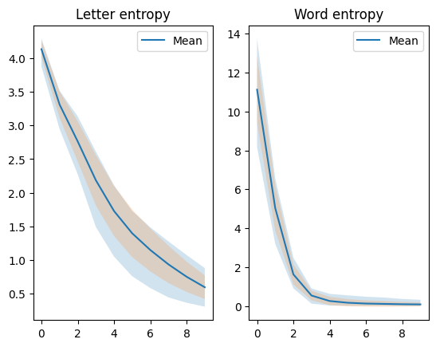

```python
stats = compute_stats(y_l, y_w)
#print_stats(stats)
plot_stats(stats)
```

```python
def analyze_samples(stats, rank, dataset = ['sample0.txt', 'sample1.txt', 'sample2.txt', 'sample3.txt', 'sample4.txt', 'sample5.txt']):
    return collect_data(rank, dataset)

def plot_analysis(stats, y_letters, y_words, dataset = ['sample0.txt', 'sample1.txt', 'sample2.txt', 'sample3.txt', 'sample4.txt', 'sample5.txt']):
    for data in dataset:
        print( 'Processing file: ', data )
        y_l_mean, y_w_mean, y_l_std, y_w_std, y_l_max, y_w_max, y_l_min, y_w_min = stats
        x = [i for i in range(len(y_l_mean))]
        plt.title('Entropy for ' + data)
        plt.subplot(1, 2, 1)
        plt.plot(x, y_l_mean, label='Mean')
        plt.fill_between(x, np.array(y_l_max), np.array(y_l_min), alpha=0.2)
        plt.fill_between(x, np.array(y_l_mean)-np.array(y_l_std), np.array(y_l_mean)+np.array(y_l_std), alpha=0.2)
        plt.legend()
        plt.title('Letter entropy')
        plt.subplot(1, 2, 2)
        plt.plot(x, y_w_mean, label='Mean')
        plt.fill_between(x, np.array(y_w_max), np.array(y_w_min), alpha=0.2)
        plt.fill_between(x, np.array(y_w_mean)-np.array(y_w_std), np.array(y_w_mean)+np.array(y_w_std), alpha=0.2)
        plt.legend()
        plt.title('Word entropy')

        y_l = y_letters[dataset.index(data)]
        y_w = y_words[dataset.index(data)]
        x = [i for i in range(len(y_l))]
        plt.subplot(1, 2, 1)
        plt.plot(x, y_l, label=data)
        plt.legend()
        plt.subplot(1, 2, 2)
        plt.plot(x, y_w, label=data)
        plt.legend()
        plt.show()
```

```python
y_letters, y_words = analyze_samples(stats, rank)
```

```
Processing file:  sample0.txt
Rank:  0 | letterEntropy:  4.273001240566634 | wordEntropy:  7.748741386140163
Rank:  1 | letterEntropy:  2.915894004347676 | wordEntropy:  7.486391705101602
Rank:  2 | letterEntropy:  2.0003592449340273 | wordEntropy:  4.406703436670285
Rank:  3 | letterEntropy:  1.539281830883116 | wordEntropy:  0.5950075484407006
Rank:  4 | letterEntropy:  1.4385817626985986 | wordEntropy:  0.012060969946616184
Rank:  5 | letterEntropy:  1.3919684277348614 | wordEntropy:  9.995642904772777e-05
Rank:  6 | letterEntropy:  1.3028454847864093 | wordEntropy:  2.0522227387178724e-06
Rank:  7 | letterEntropy:  1.1912734823426108 | wordEntropy:  -1.157754797589335e-06
Rank:  8 | letterEntropy:  1.0806251962678879 | wordEntropy:  -1.1577557268884883e-06
Rank:  9 | letterEntropy:  0.9751665583143724 | wordEntropy:  -1.1577566558918899e-06
Processing file:  sample1.txt
Rank:  0 | letterEntropy:  4.1270065107544225 | wordEntropy:  11.50069848365805
Rank:  1 | letterEntropy:  3.239149841251199 | wordEntropy:  5.372243906191295
Rank:  2 | letterEntropy:  2.8612801838294115 | wordEntropy:  1.5747378907170477
Rank:  3 | letterEntropy:  2.3266850176267684 | wordEntropy:  0.5075098825602266
Rank:  4 | letterEntropy:  1.8135104525167547 | wordEntropy:  0.2934566545167545
Rank:  5 | letterEntropy:  1.4311248153231149 | wordEntropy:  0.15056386615587047
Rank:  6 | letterEntropy:  1.1420025520817054 | wordEntropy:  0.116728201195318
Rank:  7 | letterEntropy:  0.924568099095147 | wordEntropy:  0.08657730025121572
Rank:  8 | letterEntropy:  0.7535246720393994 | wordEntropy:  0.07106935354679488
Rank:  9 | letterEntropy:  0.6099370197992321 | wordEntropy:  0.06437339444064177
Processing file:  sample2.txt
Rank:  0 | letterEntropy:  3.993311800232584 | wordEntropy:  8.023869815826423
Rank:  1 | letterEntropy:  3.0504392827806956 | wordEntropy:  7.348623164061692
Rank:  2 | letterEntropy:  2.4676602357393067 | wordEntropy:  3.7819360481550275
Rank:  3 | letterEntropy:  1.9397723261083095 | wordEntropy:  0.859504678495735
Rank:  4 | letterEntropy:  1.702032573771311 | wordEntropy:  0.08198995119837932
Rank:  5 | letterEntropy:  1.6144131896549507 | wordEntropy:  0.0029857254064618493
Rank:  6 | letterEntropy:  1.5398778328909248 | wordEntropy:  7.885470702862453e-05
Rank:  7 | letterEntropy:  1.419579524566753 | wordEntropy:  -1.2846297057087201e-06
Rank:  8 | letterEntropy:  1.2404141518502902 | wordEntropy:  -1.2846308496127768e-06
Rank:  9 | letterEntropy:  1.0146651225688108 | wordEntropy:  -1.2846319935597008e-06
Processing file:  sample3.txt
Rank:  0 | letterEntropy:  3.9302982291562376 | wordEntropy:  9.061119324709422
Rank:  1 | letterEntropy:  3.1844671446588304 | wordEntropy:  5.950220713918665
Rank:  2 | letterEntropy:  2.6278960618688427 | wordEntropy:  2.6308061657216824
Rank:  3 | letterEntropy:  2.0239917989999556 | wordEntropy:  1.2640901714391766
Rank:  4 | letterEntropy:  1.5342437344645155 | wordEntropy:  0.41432614248903776
Rank:  5 | letterEntropy:  1.2504138879380697 | wordEntropy:  0.20012202534323034
```

[output cut: 11 more lines]

```
Rank:  6 | letterEntropy:  0.7084143972151451 | wordEntropy:  -7.840944855969713e-07
Rank:  7 | letterEntropy:  0.08322413231822873 | wordEntropy:  -7.840949116911163e-07
Rank:  8 | letterEntropy:  0.006215301790297563 | wordEntropy:  -7.840953380426299e-07
Rank:  9 | letterEntropy:  0.0004241509693217184 | wordEntropy:  -7.840957641350615e-07
Processing file:  sample5.txt
Rank:  0 | letterEntropy:  4.441688109803037 | wordEntropy:  16.50952760746038
Rank:  1 | letterEntropy:  3.523098009907147 | wordEntropy:  -3.0851753152025574e-08
Rank:  2 | letterEntropy:  3.250620944571312 | wordEntropy:  -3.08517737782197e-08
Rank:  3 | letterEntropy:  2.834271259615998 | wordEntropy:  -3.085179472199201e-08
Rank:  4 | letterEntropy:  2.172440811015325 | wordEntropy:  -3.0851815026810804e-08
Rank:  5 | letterEntropy:  1.4468678793211762 | wordEntropy:  -3.0851835967395906e-08
Rank:  6 | letterEntropy:  0.8847413076661842 | wordEntropy:  -3.085185659256588e-08
Rank:  7 | letterEntropy:  0.5220494435901979 | wordEntropy:  -3.085187721058562e-08
Rank:  8 | letterEntropy:  0.29911083047101955 | wordEntropy:  -3.085189751300755e-08
Rank:  9 | letterEntropy:  0.164510561558947 | wordEntropy:  -3.0851918451361e-08
```

```
Processing file:  sample0.txt
```

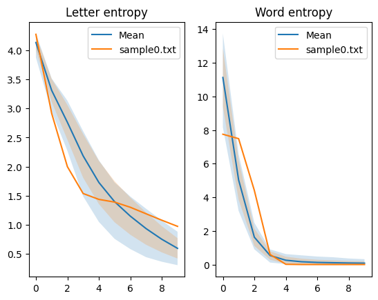

```
Processing file:  sample1.txt
```

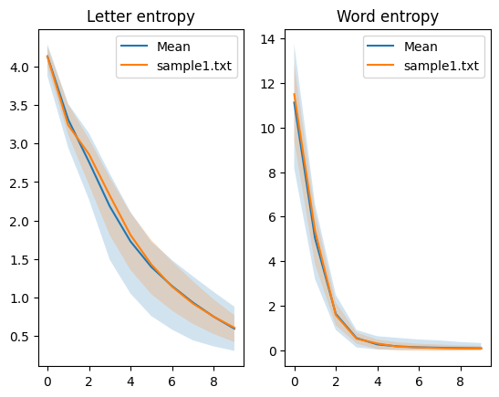

```
Processing file:  sample2.txt
```

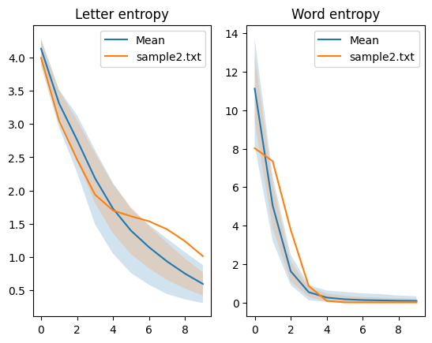

```
Processing file:  sample3.txt
```

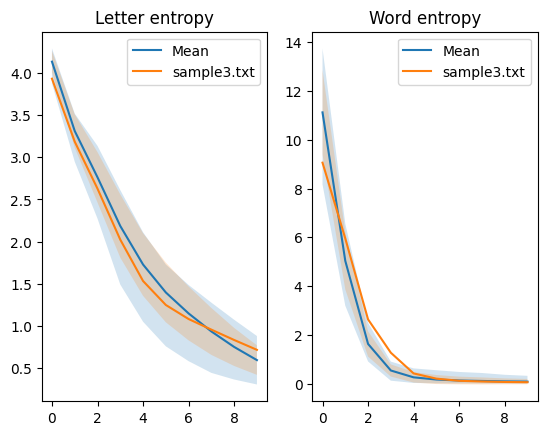

```
Processing file:  sample4.txt
```

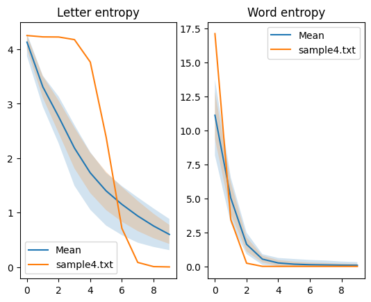

```
Processing file:  sample5.txt
```

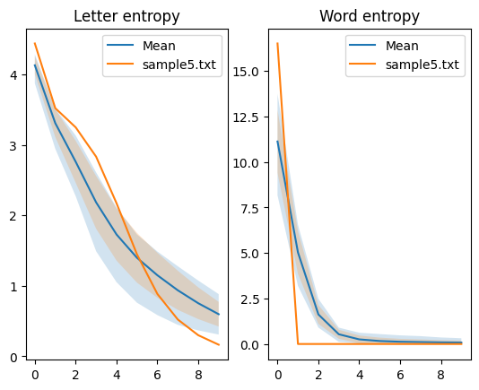

```python
plot_analysis(stats, y_letters, y_words)
```

| sam | sample0 | sample1 | sample2 | sample3 | sample4 | sample5 |
| --- | --- | --- | --- | --- | --- | --- |
| check(is_lan) | x | ✓ | x | ✓ | x | x |
| comment | needed more experiments. Although for greater data seems not to work. It was close. | greatly follows stats graph | needed more experiments. for greater data seems not to work. It looks like language though, but the words are mostly in random order | greatly follows stats graph | first few letter are always random | to big diff between rank0 and rank1, then no change |